# FVCOM Monthly Inventory Check

Documenting GMRI’s FVCOM Inventory on Box

Published

April 29, 2024

## GMRI-Box FVCOM Monthly Inventory

As part of a previous project, the FVCOM GOM3 hindcast data was downloaded for local (cloud) storage. Data was re-saved as monthly means.

This quarto doc will serve as documentation of what data was downloaded, the time/space extent, and which variables were stored.

A previous team member (Matt Dzaugis) was responsible for accessing and storing the data, and we are grateful for his time/effort in doing so.

```r
library(raster)
library(sf)
library(fvcom)
library(ncdf4)
library(tidyverse)
library(gmRi)
library(patchwork)

conflicted::conflict_prefer("select", "dplyr")

proj_path <- cs_path("mills", "Projects/Lobster ECOL")
fvcom_out <- str_c(proj_path, "FVCOM_support/")



source(here::here("R/FVCOM_Support.R"))
```

### Accessing Box Inventory

FVCOM is stored with other research community assets in the `RES_Data/FVCOM` directory.

The FVCOM Monthly Means can be found in `RES_Data/FVCOM/FVCOM_mon_means` with files labeled by year and month, yyyymm.nc :  
ex. `197801.nc`

### Check Spatial Coverage of Monthly Files

The monthly averages appear to cover the full domain of th FVCOM mesh.

Note: There is a note in Matt’s code about an issue with lon/lat details not saving for the earlier years: https://github.com/dzaugis/Ecosystem_Indicators/blob/6d21e553614cb06eb7ea02e4546535cf038d7678/Code/FVCOM_shp_extract.Rmd#L42C42-L42C43

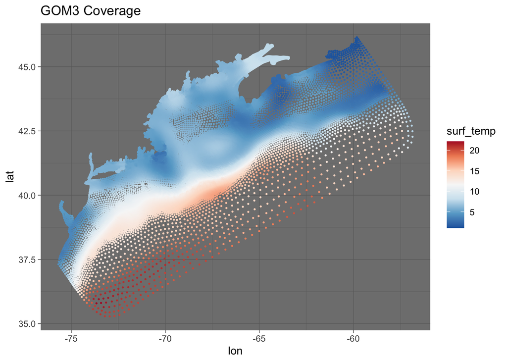

```r
# We can Access Netcdf Files Directly
box_fvcom <- cs_path("res", "FVCOM/monthly_means/gom3_mon_means")
yr <- "2010"
mon <- "01"

# Build the full path
nc_name <- str_c(box_fvcom, "gom3_monthly_mean_", yr, mon, ".nc")

# Open (lazy-load) the netcdf connection
x_gom3 <- nc_open(nc_name)


# Can also get the mesh itself as a simple feature collection
mesh <- get_mesh_geometry(x_gom3, what = 'lonlat')

# # And we can use the mesh to request variables with it
# plot(sf::st_geometry(mesh),
#      border = scales::alpha("gray", 0.6),
#      main = "GMRI Monthly FVCOM, Coverage")

# Or We can grab surface and bottom temps this way since we have to for the other files
max_depth <- dim(ncvar_get(x_gom3, "siglay"))[2]
gom3_dat <- data.frame(
  "lon" = ncvar_get(x_gom3, "lon"),
  "lat" = ncvar_get(x_gom3, "lat"),
  "surf_temp" = ncvar_get(x_gom3, "temp")[,1],
  "bot_temp" = ncvar_get(x_gom3, "temp")[,max_depth]
)


# And we can use the mesh to request variables with it
(g3_cover <- ggplot(gom3_dat) +
  geom_point(aes(lon, lat, color = surf_temp), size = 0.3) +
  # geom_line(aes(lon, lat, color = surf_temp), size = 0.3) + #lol
  scale_color_distiller(palette = "RdBu") +
  theme_dark() +
  labs(title = "GOM3 Coverage"))
```

### What Variables are Stored?

It seems like all the variables were brought along.

```r
list_vars(x_gom3) %>% gt::gt()
```

| name | dims | dim1 | dim2 | dim3 | units | longname |
| --- | --- | --- | --- | --- | --- | --- |
| nprocs |  |  |  |  |  | number of processors |
| partition | nele | nele |  |  |  | partition |
| x | node | node |  |  | meters | nodal x-coordinate |
| y | node | node |  |  | meters | nodal y-coordinate |
| lon | node | node |  |  | degrees_east | nodal longitude |
| lat | node | node |  |  | degrees_north | nodal latitude |
| xc | nele | nele |  |  | meters | zonal x-coordinate |
| yc | nele | nele |  |  | meters | zonal y-coordinate |
| lonc | nele | nele |  |  | degrees_east | zonal longitude |
| latc | nele | nele |  |  | degrees_north | zonal latitude |
| h | node | node |  |  | m | Bathymetry |
| nv | nele,three | nele | three |  |  | nodes surrounding element |
| iint | time | time |  |  |  | internal mode iteration number |
| Itime | time | time |  |  | days since 1858-11-17 00:00:00 | Itime |
| Itime2 | time | time |  |  | msec since 00:00:00 | Itime2 |
| Times | DateStrLen,time | DateStrLen | time |  |  | Times |
| nbe | nele,three | nele | three |  |  | elements surrounding each element |
| ntsn | node | node |  |  |  | #nodes surrounding each node |
| nbsn | node,maxnode | node | maxnode |  |  | nodes surrounding each node |
| ntve | node | node |  |  |  | #elems surrounding each node |
| nbve | node,maxelem | node | maxelem |  |  | elems surrounding each node |
| a1u | nele,four | nele | four |  |  | a1u |
| a2u | nele,four | nele | four |  |  | a2u |
| aw0 | nele,three | nele | three |  |  | aw0 |
| awx | nele,three | nele | three |  |  | awx |
| awy | nele,three | nele | three |  |  | awy |
| art2 | node | node |  |  |  | Area of elements around a node |
| art1 | node | node |  |  |  | Area of Node-Base Control volume |
| zeta | node,time | node | time |  | meters | Water Surface Elevation |
| u | nele,siglay,time | nele | siglay | time | meters s-1 | Eastward Water Velocity |
| v | nele,siglay,time | nele | siglay | time | meters s-1 | Northward Water Velocity |
| omega | node,siglev,time | node | siglev | time | s-1 | Vertical Sigma Coordinate Velocity |
| ww | nele,siglay,time | nele | siglay | time | meters s-1 | Upward Water Velocity |
| ua | nele,time | nele | time |  | meters s-1 | Vertically Averaged x-velocity |
| va | nele,time | nele | time |  | meters s-1 | Vertically Averaged y-velocity |
| vorticity | node,time | node | time |  | s-1 | Ertels 2d potential vorticity |
| temp | node,siglay,time | node | siglay | time | degrees_C | temperature |
| salinity | node,siglay,time | node | siglay | time | 1e-3 | salinity |
| short_wave | node,time | node | time |  | W m-2 | Short Wave Radiation |
| net_heat_flux | node,time | node | time |  | W m-2 | Surface Net Heat Flux |
| precip | node,time | node | time |  | m s-1 | Precipitation |
| evap | node,time | node | time |  | m s-1 | Evaporation |

### Time

We should have one time-step,per file, just confirming that. Confirmed

```r
fvcom_time(x_gom3) %>% as.Date()
```

```
[1] "2010-01-17"
```

### Depth: siglev/siglay

Depth information is contained in two coordinates, “siglay” and “siglev” which are shorthand for sigma layer and sigma level. These are values between zero and -1 and refer to the fraction of the total depth of that location. 0 = surface, -1 = bottom. There are 45 sigma levels in GOM3.

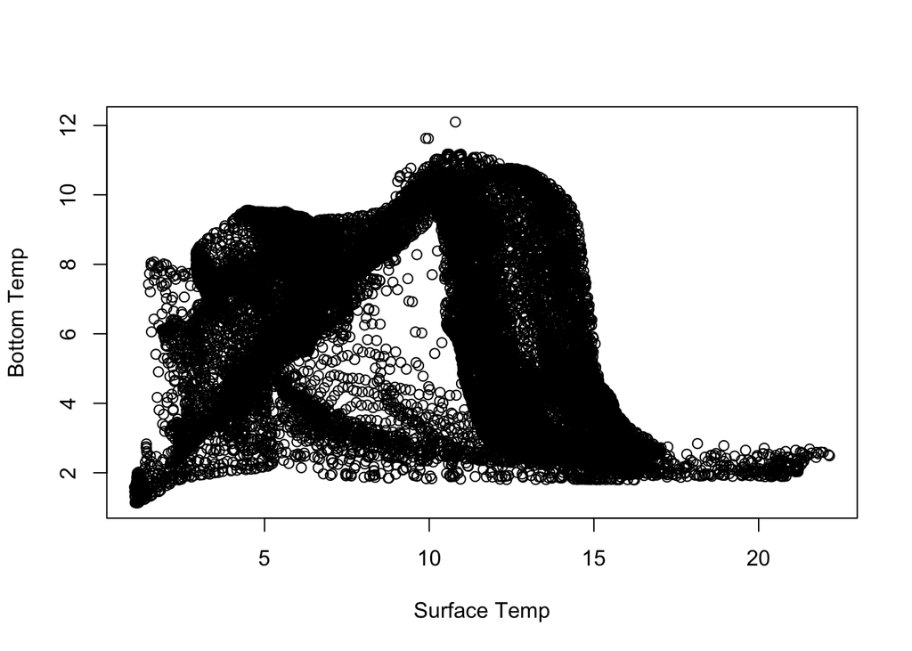

```r
# range(x_gom3$dim$siglev$vals)
# range(x_gom3$dim$siglay$vals)


# Here is how matt handled surface and bottom indexing:
sigLevel <- x_gom3$dim$siglay$len
sur_temp <- ncdf4::ncvar_get(x_gom3, varid = "temp")[,1]
bot_temp <- ncdf4::ncvar_get(x_gom3, varid = "temp")[,sigLevel]

# From here we have surface temperature and bottom temperature as vectors
plot(sur_temp, bot_temp, xlab = "Surface Temp", ylab = "Bottom Temp")
```

```r
# We need the lat/lon node information as well
lon <- ncdf4::ncvar_get(x_gom3, varid = "lon")
lat <- ncdf4::ncvar_get(x_gom3, varid = "lat")


# And we need the surface Currents as well
u <- ncdf4::ncvar_get(x_gom3, varid = "u")[,1]
v <- ncdf4::ncvar_get(x_gom3, varid = "v")[,1]

# And the coordinates for the zonal centers
lonc <- ncdf4::ncvar_get(x_gom3, varid = "lonc")
latc <- ncdf4::ncvar_get(x_gom3, varid = "latc")
```

## Using fvcom::mesh to get mesh node indices

The node ID’s that come from the mesh simple feature collections that Ben’s package generate may be passed directly as index numbers to these variable vectors. Alternatively the FVCOM r package can be used to get process means over a number of time steps.

### Using {fvcom} to Generate a Mesh and Trim it to Areas

By loading the FVCOM mesh as a simple features dataframe we can use geoprocessing functions from {sf} to clip the mesh using shapefiles for areas of interest.

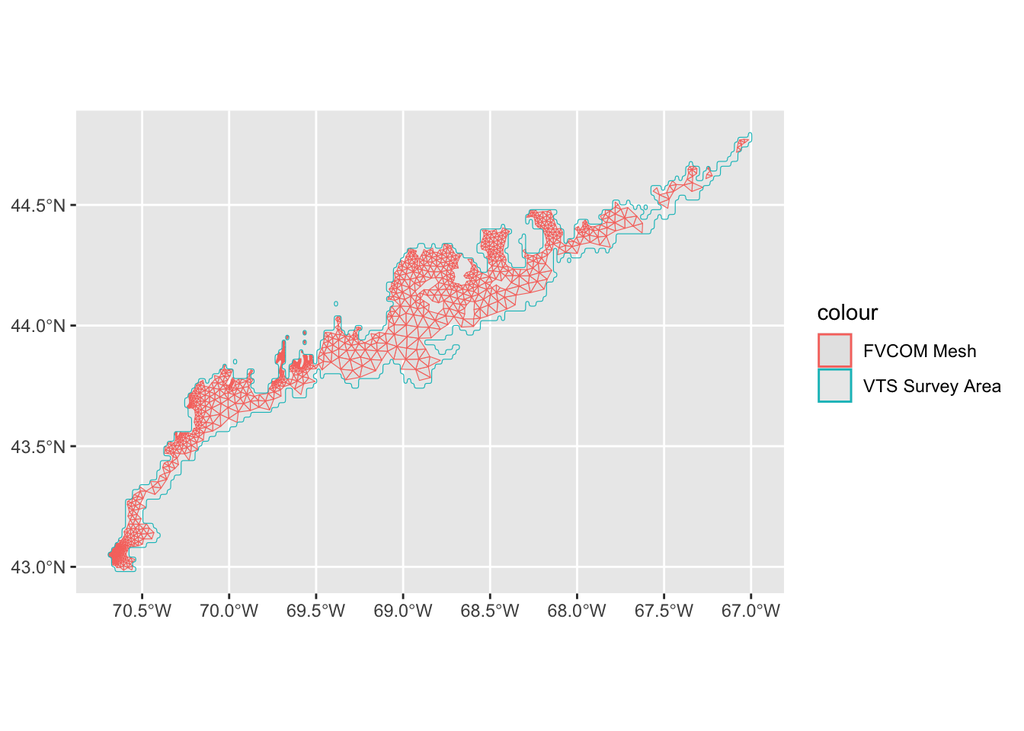

```r
# Do the cropping routine directly on the mesh for these monthly files

# Read things in
vts_poly           <- read_sf(str_c(proj_path, "Ecological Data/Spatial_Boundaries/VTSsurvey_nearshore_area.geojson"))
res_shapes         <- cs_path("res", "Shapefiles")
epu_path           <- str_c(res_shapes, "EPU/")
gom_poly           <- read_sf(str_c(epu_path, "individual_epus/GOM.geojson"))
gb_poly            <- read_sf(str_c(epu_path, "individual_epus/GB.geojson"))
shelf_poly         <- read_sf(str_c(epu_path, "EPU_extended.shp"))
st_crs(shelf_poly) <- st_crs(gom_poly)


#--------------------
# Prep CRS for polygons
gom_poly <- st_transform(gom_poly, st_crs(mesh))
gb_poly    <- st_transform(gb_poly, st_crs(mesh))
vts_poly   <- st_transform(vts_poly, st_crs(mesh))





# Flag the locations that are within the domain
vts_mesh <- mesh_trim(mesh = mesh, domain = vts_poly)

# Plot how the clipping looks on a map
ggplot() +
  geom_sf(data = vts_mesh, aes(color = "FVCOM Mesh")) +
  geom_sf(data = vts_poly, aes(color = "VTS Survey Area"), fill = "transparent") +
  labs("Mesh Triangles Within Gulf of Maine")
```

The node ID’s match up, but we need to be careful and be sure that we’re using the right mesh for the right dataset. The FVCOM mesh has evolved with different model iterations so being sure that we have the right mesh will be important. After 2016 we will need to repeat the step used to identify nodes.

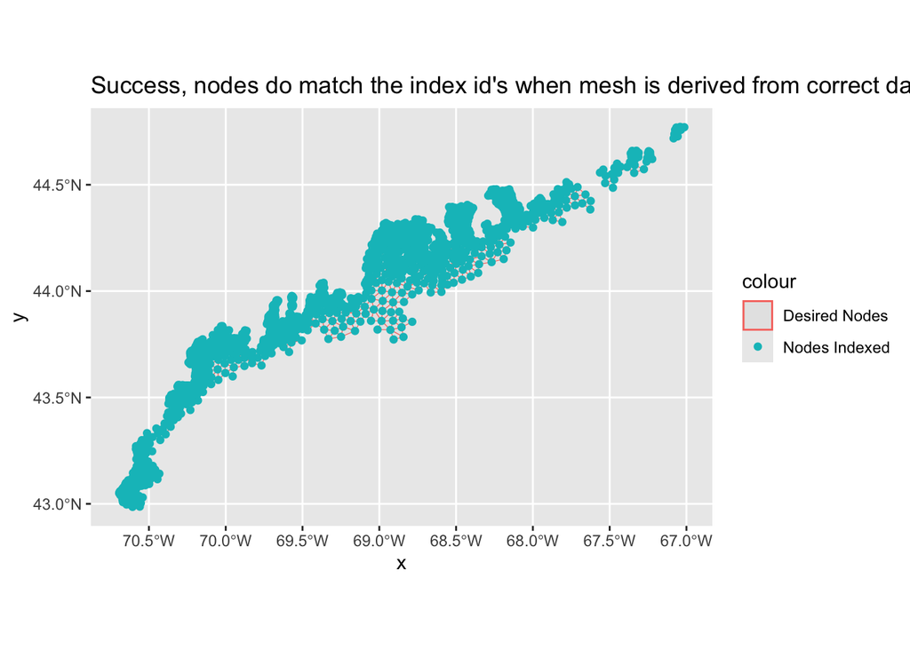

```r
# Do the node ids work this time? YES, so we need to be careful so that we match the mesh to the dataset

# We need the lat/lon node information as well
lon <- ncdf4::ncvar_get(x_gom3, varid = "lon")
lat <- ncdf4::ncvar_get(x_gom3, varid = "lat")

# Mesh has index information for zonal elements and nodes
node_ids <- st_drop_geometry(vts_mesh) %>%
  select(-elem) %>%
  pivot_longer(cols = everything(),
               names_to = "triangle_point",
               values_to = "node_id") %>%
  distinct(node_id) %>%
  pull()


# Subset lat & lon using those indices
lat_vts  <- lat[node_ids]
lon_vts  <- lon[node_ids]


data.frame(x = lon_vts, y = lat_vts) %>%
  ggplot() +
  geom_sf(data = vts_mesh, aes(color = "Desired Nodes"))+
  geom_point(aes(x, y, color = "Nodes Indexed")) +
  labs(title = "Success, nodes do match the index id's when mesh is derived from correct dataset")
```

# Building VTS Mesh Monthly Inventory

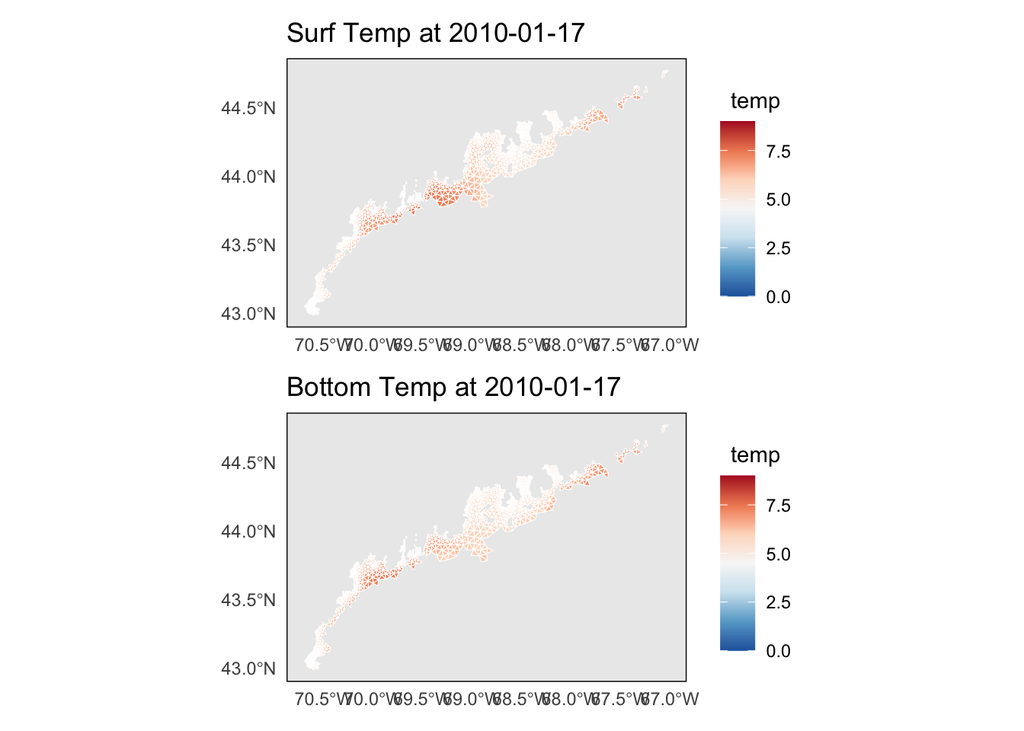

```r
# Clip worked fine, now can we get the ID's to match:
# Or do we need to?
# We can just use fvcom to get variables for each month over the area
# These are the core variables at the nodes
node_var_list <- c('temp', 'salinity')

# Can we pass multiple time indices to get vars
# ncvar_get(x, "time") # Isn't in time units
time_dim <- fvcom_time(x_gom3)


# Then Can we Grab what we want?
surface_vars <- get_mesh(
  x_gom3, # Dataset lazyloaded with ncdf4 from THREDDS
  y = 1, # integer, or indices for siglay or siglev (depth indices)
  vars = c(node_var_list),  # Variables we want
  mesh = vts_mesh, # Mesh to get them for
  time = c(1:length(time_dim)), # All time intervals
  )

bottom_vars <- get_mesh(
  x_gom3, # Dataset lazyloaded with ncdf4 from THREDDS
 y = dim(ncvar_get(x_gom3, "siglay"))[2],
  vars = c(node_var_list),  # Variables we want
  mesh = vts_mesh, # Mesh to get them for
  time = c(1:length(time_dim)), # All time intervals
  )

#  Plot Them
p1 <- ggplot(surface_vars) +
  geom_sf(aes(fill = temp), color = "white") +
  scale_fill_distiller(palette = "RdBu", limits = c(0,9)) +
  map_theme() +
  labs(title = str_c("Surf Temp at ", time_dim[1]))

#  Plot Them
p2 <- ggplot(bottom_vars) +
  geom_sf(aes(fill = temp), color = "white") +
  scale_fill_distiller(palette = "RdBu", limits = c(0,9)) +
  map_theme() +
  labs(title = str_c("Bottom Temp at ", time_dim[1]))


p1 / p2
```

# Post-2016 Inventory

After 2016 the hindcast/fvcom data available as monthly files transitions. These have been downloaded from the Seaplan hindcast archive, but need to be checked for what variables they contain and how the mesh varies between them.

## 2017 FVCOM-GOM5

For some reason the monthly hindcast files for 2017 come from GOM5. This is what they look like. They contain the lat/lon/time dimensions of the GOM% mesh, but they only have temperature.

They also lack the variables that list the surrounding nodes and elements which the FVCOM package uses to identify the polygons.

```r
# Get some file names
gom5_files <- monthly_fvcom_inventory(
  start_yr = 2017,
  end_y = 2017,
  fvcom_folder = cs_path("res", "FVCOM/monthly_means"),
  fvcom_vers = "GOM5"
)

# Open 1:
x_gom5 <- nc_open(gom5_files[[1]])


# Only has Temperature
list_vars(x_gom5) %>% gt::gt()
```

| name | dims | dim1 | dim2 | dim3 | units | longname |
| --- | --- | --- | --- | --- | --- | --- |
| x | node | node |  |  | meters | nodal x-coordinate |
| y | node | node |  |  | meters | nodal y-coordinate |
| lon | node | node |  |  | degrees_east | nodal longitude |
| lat | node | node |  |  | degrees_north | nodal latitude |
| h | node | node |  |  | m | Bathymetry |
| temp | node,siglay,time | node | siglay | time | degrees_C | temperature |

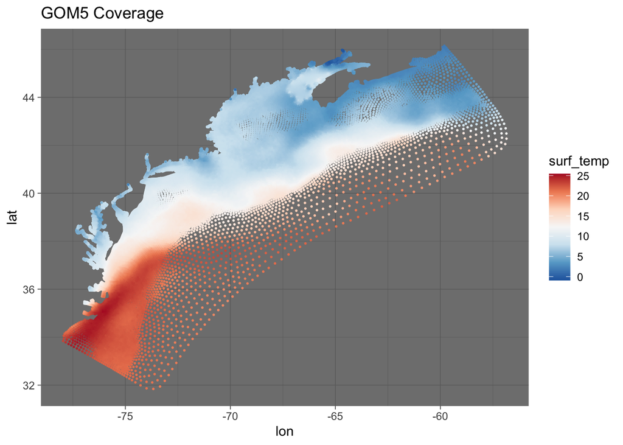

```r
# the FVCOm package doesn't like how the CRS is stored in the file attributes and breaks
# We can use some functions but not the mesh ones
gom5_nodes <- fvcom_nodes(x_gom5)

# # These fail
# gom5_mesh <- get_mesh_geometry(x_gom5, what = 'lonlat')
# fvcom_crs(x_gom5)


# We can still manually index lat/lon/temp for surface and bottom temps
max_depth <- dim(ncvar_get(x_gom5, "siglay"))[2]
gom5_dat <- data.frame(
  "lon" = ncvar_get(x_gom5, "lon"),
  "lat" = ncvar_get(x_gom5, "lat"),
  "surf_temp" = ncvar_get(x_gom5, "temp")[,1],
  "bot_temp" = ncvar_get(x_gom5, "temp")[,max_depth]
)


# And we can use the mesh to request variables with it
(g5_cover <- ggplot(gom5_dat) +
  geom_point(aes(lon, lat, color = surf_temp), size = 0.3) +
  # geom_line(aes(lon, lat, color = surf_temp), size = 0.3) + #lol
  scale_color_distiller(palette = "RdBu") +
  theme_dark() +
  labs(title = "GOM5 Coverage"))
```

## 2018-2020 FVCOM-GOM4

```r
# Get some file names
gom4_files <- monthly_fvcom_inventory(
  start_yr = 2018,
  end_y = 2018,
  fvcom_folder = cs_path("res", "FVCOM/monthly_means"),
  fvcom_vers = "GOM4"
)

# Open 1:
x_gom4 <- nc_open(gom4_files[[1]])


# Only has Temperature
list_vars(x_gom4) %>% gt::gt()
```

| name | dims | dim1 | dim2 | dim3 | units | longname |
| --- | --- | --- | --- | --- | --- | --- |
| x | node | node |  |  | meters | nodal x-coordinate |
| y | node | node |  |  | meters | nodal y-coordinate |
| lon | node | node |  |  | degrees_east | nodal longitude |
| lat | node | node |  |  | degrees_north | nodal latitude |
| h | node | node |  |  | m | Bathymetry |
| temp | node,siglay,time | node | siglay | time | degrees_C | temperature |

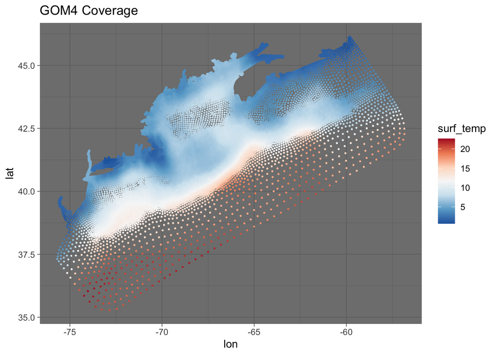

```r
# the FVCOm package doesn't like how the CRS is stored in the file attributes and breaks
# We can use some functions but not the mesh ones
gom4_nodes <- fvcom_nodes(x_gom4)

# # These fail
# gom4_mesh <- get_mesh_geometry(x_gom4, what = 'lonlat')
# fvcom_crs(x_gom4)


# We can still manually index lat/lon/temp for surface and bottom temps
max_depth <- dim(ncvar_get(x_gom4, "siglay"))[2]
gom4_dat <- data.frame(
  "lon" = ncvar_get(x_gom4, "lon"),
  "lat" = ncvar_get(x_gom4, "lat"),
  "surf_temp" = ncvar_get(x_gom4, "temp")[,1],
  "bot_temp" = ncvar_get(x_gom4, "temp")[,max_depth]
)


# And we can use the mesh to request variables with it
(g4_cover <- ggplot(gom4_dat) +
  geom_point(aes(lon, lat, color = surf_temp), size = 0.3) +
  # geom_line(aes(lon, lat, color = surf_temp), size = 0.3) + #lol
  scale_color_distiller(palette = "RdBu") +
  theme_dark() +
  labs(title = "GOM4 Coverage"))
```

```r
nrow(gom3_dat)
nrow(gom4_dat)
nrow(gom5_dat)
bind_rows(
  list(
    "FVCOM-GOM3: 1978-2016" = gom3_dat,
    "FVCOM-GOM4: 2018-2020" = gom4_dat,
    "FVCOM-GOM5: 2017" = gom5_dat),
  .id = "FVCOM Version") %>%
  ggplot()  +
  geom_point(aes(lon, lat, color = bot_temp), size = 0.3) +
  # geom_line(aes(lon, lat, color = surf_temp), size = 0.3) + #lol
  scale_color_distiller(palette = "RdBu") +
  theme_dark() +
  theme(strip.text = element_text(face = "bold"),
        plot.title = element_text(size = 14, face = "bold"),
        plot.subtitle = element_text(size = 12)) +
  facet_wrap(~`FVCOM Version`) +
  labs(title = "FVCOM Mesh Coverage Differences",
       subtitle = "GOM3 & GOM4: n = 53,087 nodes\nGOM5: n = 136,432 nodes")
```

[output not shown]